# Introducción a R paso a paso

24 de noviembre de 2015

## Qué es R?

## Origen

- El `R` es una implementación del lenguaje de programación específico de estadística **S**
- Ideado por **Ross Ihaka** y **Robert Gentleman** en la Universidad de Auckland, New Zealand
- Empiezan en el año 1993. Considerado estable a partir del 2000.

## Ventajas

- *'Free'*
- Multi-plataforma
- Pensado para análisis de datos
- Programable
- *'Reproducible Research'*
- Activa comunidad de usuarios

## Qué es el CRAN?

- [The Comprehensive R Archive Network](http://cran.r-project.org/)
- Repositorio oficial del R, librerías y manuales
- 7515 [librerías](http://cran.r-project.org/web/packages/) adicionales
- [Task View](http://cran.r-project.org/web/views/)
- [Manuales](http://cran.r-project.org/manuals.html)
- [The R Journal](https://journal.r-project.org/)

## Cómo buscar ayuda en Internet?

- [StackOverflow](http://stackoverflow.com/questions/tagged/r) Más de 100000 preguntas.
- [R-help](https://stat.ethz.ch/pipermail/r-help/) Preguntas y respuestas oficial
- [R-help.es](https://stat.ethz.ch/mailman/listinfo/r-help-es), Preguntas y respuestas en castellano
- [Quick R](http://www.statmethods.net/) Web con instrucciones prácticas
- [R Cookbook](http://www.cookbook-r.com/) Web con *recetas* de R prácticas
- [RDocumentation](http://www.rdocumentation.org/) Ayuda de R on-line de todos los pacakges

Preguntar claramente y con un [ejemplo reproducible](http://stackoverflow.com/questions/5963269/how-to-make-a-great-r-reproducible-example).

## RStudio

[figure not shown]

## Qué es RStudio?

- [IDE](http://www.rstudio.com/products/rstudio/) *(entorno integrado de desarrollo)*
- Empresa:
  - Ofrece formación y opciones de pro de sus desarrollos
  - J.J. Allaire, Hadley Wickham, Yihui Xie, etc.
  - packages importantes: `ggplot2, rmarkdown, knitr, plyr/dplyr, devtools, reshape2/tidyR`
  - [Shiny](http://shiny.rstudio.com/gallery/)

## Entorno de programación

- Proyectos
- Git
- Simplifica construir paquetes
- Informes automáticos de forma fácil
- Integración con C ++

## Instalación de R y RStudio

El **R** desde el [CRAN](https://cran.r-project.org/).

El **RStudio** desde la web en [Product -> RStudio](https://www.rstudio.com/products/rstudio/download/)

**Nota:** El R se puede usar solo. RStudio necesita el R.

## Paso 0: Familiarizarse con RStudio

## Las principales ventanas

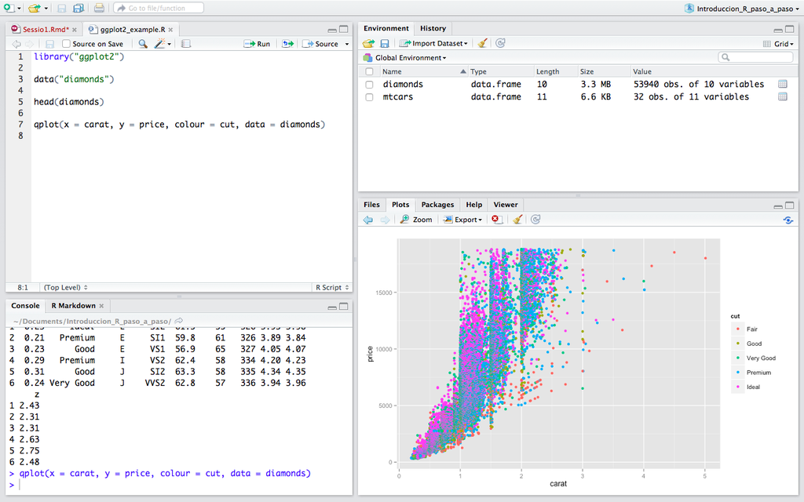

## Como buscar ayuda?

- Ventana `Help`
- Apretar F1 sobre una función, `?` o con la función `help`.

```r
?sum
help(mean)
```

- Para buscar cualquier cosa relacionada `??`

```r
??read
```

## Como instalar un package?

- Ventana `Packages` –> *Install*
- Directamente en la consola

```r
install.packages('rmarkdown')
```

## Paso 1: Conceptos iniciales

## Aritmética básica

```r
25 + 3 # 25 - 3
```

```
## [1] 28
```

```r
23 # 2/3
```

```
## [1] 23
```

```r
12 > 4 # 12 >= 4; 12 < 4; 12 <= 4
```

```
## [1] TRUE
```

```r
!TRUE # (negación); TRUE & FALSE (and); TRUE | FALSE (or)
```

```
## [1] FALSE
```

## Tipos básicos

```r
class(2)
```

```
## [1] "numeric"
```

```r
class(2L)
```

```
## [1] "integer"
```

```r
class("2")
```

```
## [1] "character"
```

```r
class(TRUE)
```

```
## [1] "logical"
```

## Tipos especiales

```r
NULL # NULL object
```

```r
NA # missing value indicator (not available)
```

```
## [1] NA
```

```r
NaN # 0/0 (not a number)
```

```
## [1] NaN
```

```r
Inf # Infinity
```

```
## [1] Inf
```

## Paso 2: Vectores, matrices y data.frames

## Estructuras de datos

**Datos homogéneos**:

- vector 1D
- matrix 2D (Formato tabla)
- arrays nD

**Datos heterogéneos**:

- list 1D
- `data.frames` 2D (Formato BBDD habitual)

## Vectores

```r
c(1,2,3)
```

```
## [1] 1 2 3
```

```r
c("a", "b", "c", "d")
```

```
## [1] "a" "b" "c" "d"
```

```r
c(TRUE, TRUE, FALSE, TRUE)
```

```
## [1]  TRUE  TRUE FALSE  TRUE
```

## Secuencias

```r
1:3
```

```
## [1] 1 2 3
```

```r
seq(1, 3)
```

```
## [1] 1 2 3
```

```r
seq(from = 10, to = 0, by = -2)
```

```
## [1] 10  8  6  4  2  0
```

## Operaciones con vectores

```r
c(1,2,3)
```

```
## [1] 1 2 3
```

```r
c(1,2,3) - c(0, 2, 1)
```

```
## [1] 1 0 2
```

```r
c(1,2,3) + c(0, 2, 1)
```

```
## [1] 1 4 4
```

```r
c(1,2,3) %*% c(0, 2, 1)
```

```
##      [,1]
## [1,]    7
```

## Evaluación de vectores

```r
un_vector <- c("a", "b", "c", "d") # <-(=) asigna a una variable
un_vector[1]
```

```
## [1] "a"
```

```r
un_vector[c(2,3)]
```

```
## [1] "b" "c"
```

```r
un_vector[-1]
```

```
## [1] "b" "c" "d"
```

```r
un_vector[c(TRUE, TRUE, FALSE, TRUE)]
```

```
## [1] "a" "b" "d"
```

## Factores

- Tipo especial por una variable categórica
- Útil para muchas funciones, por ej. regresión logística

```r
numFac <- factor(c(13,22,38, 13))
numFac
```

```
## [1] 13 22 38 13
## Levels: 13 22 38
```

```r
as.numeric(numFac)
```

```
## [1] 1 2 3 1
```

```r
as.numeric(as.character(numFac)) # convertir a numeric
```

```
## [1] 13 22 38 13
```

## data.frame

```r
un_df <- data.frame(x = 1:25, y = runif(25), ynorm = rnorm(25),
                    z = sample(c("a", "b", "c", "d"), 25, replace = TRUE),
                    t = "RUGBCN")
head(un_df) # tail(un_df)
```

```
##   x         y      ynorm z      t
## 1 1 0.9956050  0.6770899 d RUGBCN
## 2 2 0.8284240 -1.2556696 d RUGBCN
## 3 3 0.9692599  1.8618999 b RUGBCN
## 4 4 0.7036978 -2.4980486 a RUGBCN
## 5 5 0.2674196 -2.3462070 d RUGBCN
## 6 6 0.8795207 -0.1480149 d RUGBCN
```

## Explorando un data.frame

```r
dim(un_df) # nrow(un_df) ncol(un_df)
```

```
## [1] 25  5
```

```r
names(un_df) # colnames(un_df) rownames(un_df)
```

```
## [1] "x"     "y"     "ynorm" "z"     "t"
```

```r
summary(un_df)
```

```
##        x            y              ynorm         z          t
##  Min.   : 1   Min.   :0.0670   Min.   :-2.4980   a:7   RUGBCN:25
##  1st Qu.: 7   1st Qu.:0.2674   1st Qu.:-1.2012   b:5
##  Median :13   Median :0.4896   Median :-0.1457   c:5
##  Mean   :13   Mean   :0.5121   Mean   :-0.2281   d:8
##  3rd Qu.:19   3rd Qu.:0.7037   3rd Qu.: 0.5735
##  Max.   :25   Max.   :0.9956   Max.   : 1.8619
```

## Acceder a elementos de un data.frame

```r
un_df[1, 2]
```

```
## [1] 0.995605
```

```r
un_df[1, 1:3]
```

```
##   x        y     ynorm
## 1 1 0.995605 0.6770899
```

```r
un_df[1, ]
```

```
##   x        y     ynorm z      t
## 1 1 0.995605 0.6770899 d RUGBCN
```

```r
un_df$x[2]
```

```
## [1] 2
```

```r
un_df[1, c("x", "y")]
```

```
##   x        y
## 1 1 0.995605
```

```r
cond <- un_df$x > 20
un_df[cond, ]
```

```
##     x          y      ynorm z      t
## 21 21 0.68035988 -0.4926122 d RUGBCN
## 22 22 0.07550184 -1.5778731 d RUGBCN
## 23 23 0.23681802  0.5657970 a RUGBCN
## 24 24 0.70004275  0.1931108 a RUGBCN
## 25 25 0.84435685 -0.1456663 a RUGBCN
```

## Paso 3: Funciones básicas

```r
max, min, prod, sum
cummax, cummin, cumprod, cumsum, diff
range
mean, median, cor, sd, var
```

```r
max(un_df$ynorm)
```

```
## [1] 1.8619
```

```r
mean(un_df$ynorm)
```

```
## [1] -0.228119
```

```r
sd(un_df$ynorm)
```

```
## [1] 1.176321
```

```r
head(un_df) # tail
```

```
##   x         y      ynorm z      t
## 1 1 0.9956050  0.6770899 d RUGBCN
## 2 2 0.8284240 -1.2556696 d RUGBCN
## 3 3 0.9692599  1.8618999 b RUGBCN
## 4 4 0.7036978 -2.4980486 a RUGBCN
## 5 5 0.2674196 -2.3462070 d RUGBCN
## 6 6 0.8795207 -0.1480149 d RUGBCN
```

```r
summary(un_df)
```

```
##        x            y              ynorm         z          t
##  Min.   : 1   Min.   :0.0670   Min.   :-2.4980   a:7   RUGBCN:25
##  1st Qu.: 7   1st Qu.:0.2674   1st Qu.:-1.2012   b:5
##  Median :13   Median :0.4896   Median :-0.1457   c:5
##  Mean   :13   Mean   :0.5121   Mean   :-0.2281   d:8
##  3rd Qu.:19   3rd Qu.:0.7037   3rd Qu.: 0.5735
##  Max.   :25   Max.   :0.9956   Max.   : 1.8619
```

```r
table(un_df$z)
```

```
##
## a b c d
## 7 5 5 8
```

## Fusionar data.frames

- `?rbind`/`cbind`: Combinar objectos por filas o columnas
- `merge`: Combinar `data.frame` por columnas iguales
- Mirar `Ejemplo.R`

## Agrupar y resumir datos

Familia funciones `?tapply`, `?apply`, `?lapply`, `?aggregate`, etc.

Aplica una función sobre uno lista datos.

```r
tapply(un_df$y, list(un_df$z), FUN = 'sum')
```

```
##        a        b        c        d
## 3.374749 2.623353 1.988986 4.816182
```

- Existen `packages` más rápidos como [`data.table`](https://cran.r-project.org/web/packages/data.table/index.html) (Más ràpido) y [`dplyr`](https://cran.r-project.org/web/packages/dplyr/index.html)(Más fácil).

Basado en Advanced R. El capitulo [Vocabulary](http://adv-r.had.co.nz/Vocabulary.html) contiene un amplio conjunto de funciones útiles. A continuación una muestra:

```r
# Ordering and tabulating
duplicated, unique
merge
order, rank, quantile
sort
table, ftable

# Linear models
fitted, predict, resid, rstandard
lm, glm
anova, coef, confint, vcov

# Random variables
(q, p, d, r) * (beta, binom, cauchy, chisq, exp, f, gamma, geom,
  hyper, lnorm, logis, multinom, nbinom, norm, pois, signrank, t,
  unif, weibull, wilcox, birthday, tukey)
```

## Paso 4: Gráficos

- Función base `?plot`

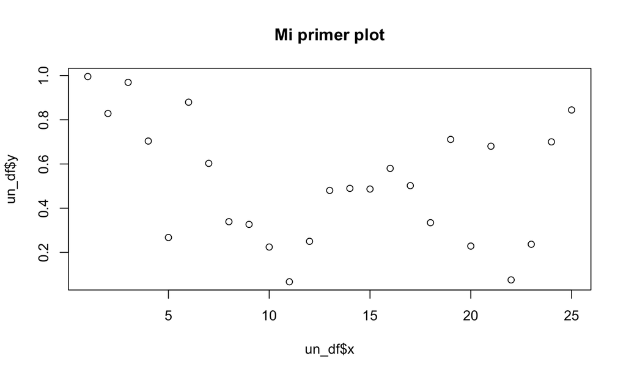

```r
plot(un_df$x, un_df$y, main = "Mi primer plot")
```

- Opciones del `plot` en `?par`
- [Parámetros para gráficos](http://www.statmethods.net/advgraphs/parameters.html)

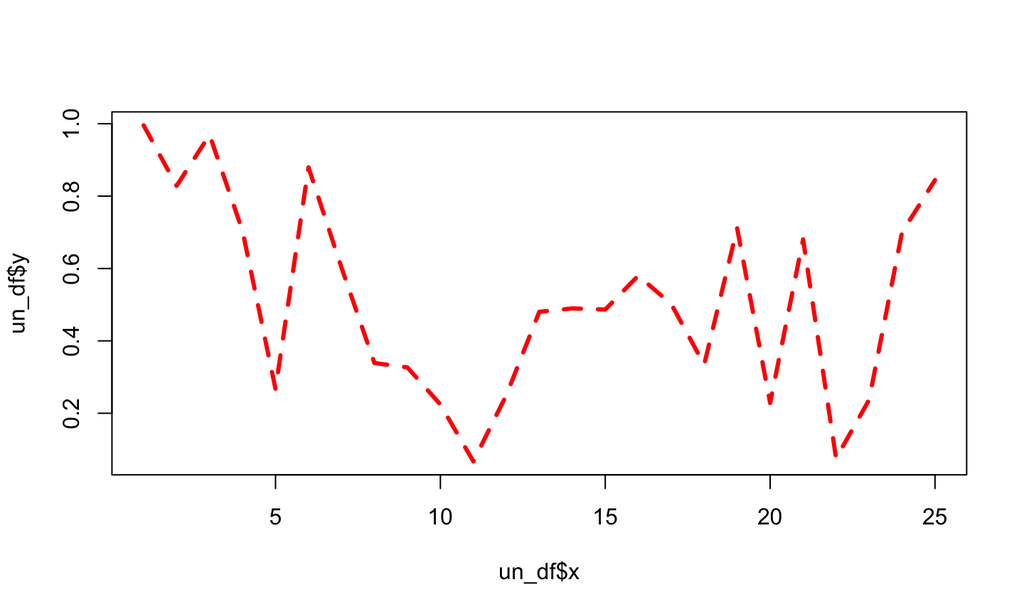

```r
plot(un_df$x, un_df$y, type = "l", col = "red", lwd = 3, lty = 2)
```

- Añadir anotaciones y títulos con `?title` `(ann = FALSE)`

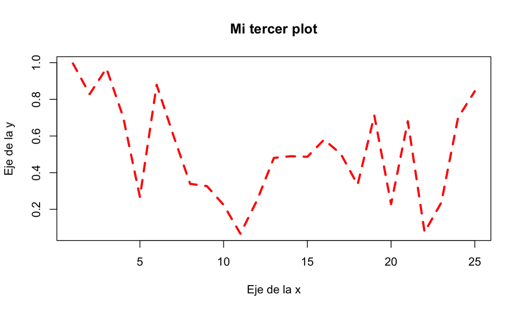

```r
plot(un_df$x, un_df$y, type = "l", col = "red", lwd = 3, lty = 2,  ann = FALSE)
title(main ="Mi tercer plot", xlab = "Eje de la x", ylab = "Eje de la y")
```

- Añadir una leyenda con `?legend`

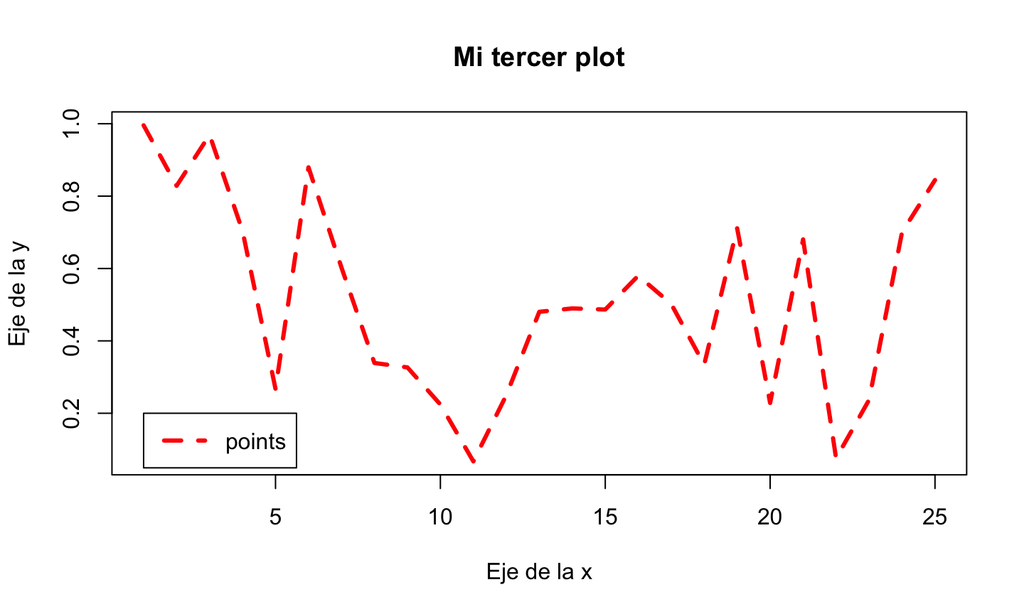

```r
plot(un_df$x, un_df$y, type = "l", col = "red", lwd = 3, lty = 2,  ann = FALSE)
title(main ="Mi tercer plot", xlab = "Eje de la x", ylab = "Eje de la y")
legend(1, 0.2, "points", lwd = 3, lty = 2, col = "red")
```

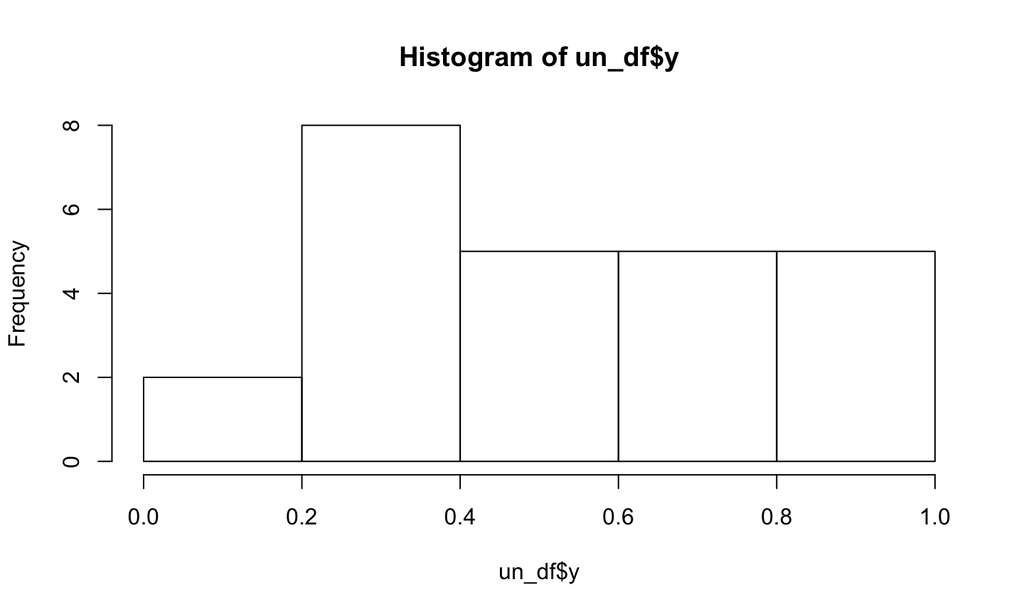

```r
hist(un_df$y)
```

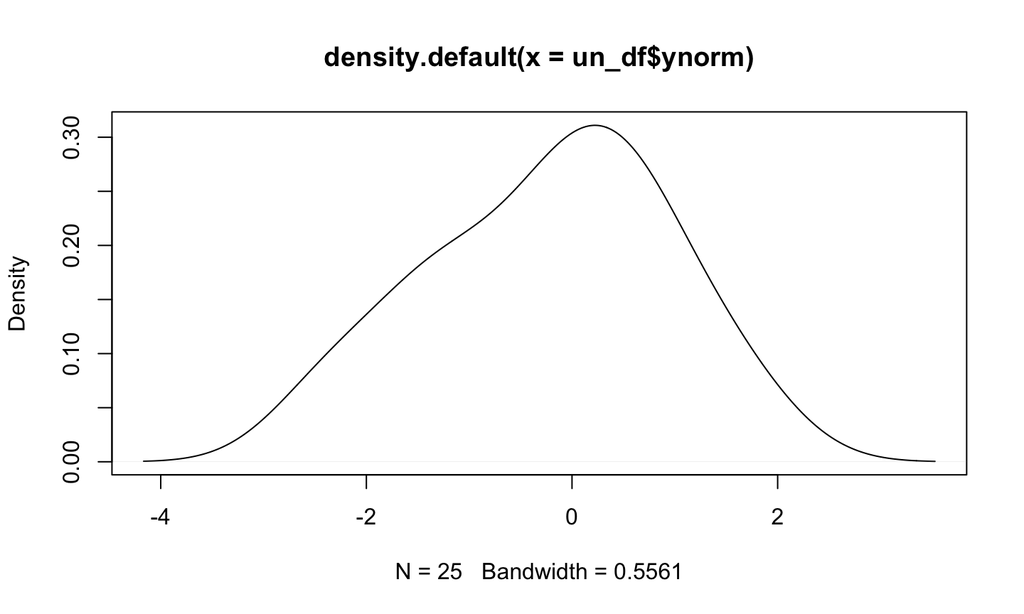

```r
densidad <- density(un_df$ynorm)
plot(densidad)
```

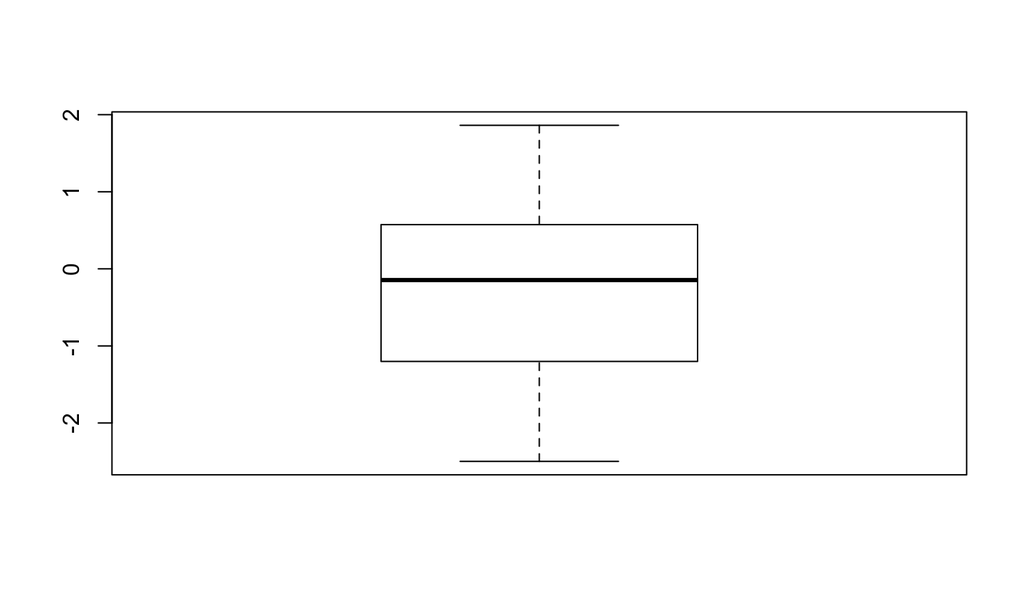

```r
boxplot(un_df$ynorm)
```

## Gráficos avanzados con ggplot2

- Basado en el Grammar of graphics (Leland Wilkinson)
- Implementado en R (Hadley Whickham)
- [Ejemplos de Google Images](http://google.com/images?q=ggplot2)
- No es fácil pero muy útil

## Paso 5: Importar y exportar datos

## Importar datos

- Desde ventana `Environment` –> *Import Dataset*
- Función `?read.table` y familiares

```r
read.table("mtcars.txt", header = TRUE)
read.csv2("mtcars.csv", header = TRUE)
```

- Package `foreign` y `heaven` permiten importar diferentes formatos como sas, spss, dbf, stata, etc
- Package `XLConnect` permite importar Excel.

## Exportar datos

- Función `?write.table` y familiares

```r
write.table(mtcars, file = "mtcars.csv")
write.csv2(mtcars, file = "mtcars.csv")
```

- Package `XLConnect` permite exportar a Excel.

## Exportar gráficos

- Desde ventana `Plots` –> *Export*
- Función `?png` y familiares

```r
png("Primer_plot.png", width = 640, height = 480)
plot(rnorm(10))
dev.off()
```

## Gracias

¿Dudas? ¿Sugerencias? ¿Insultos?

**Lluís Ramon**

[@LluisR_Tgn](https://twitter.com/LluisR_Tgn)

[@LluisRamon](https://github.com/LluisRamon)

lluisramon